# Principal Components Analysis for Data Reduction

## Semeion Handwritten Digit

—————————————————–  
Data Set Characteristics: Multivariate  
Number of Instances: 1593  
Area: Computer  
Attribute Characteristics: Integer  
Number of Attributes: 256  
Date Donated: 2008-11-11  
Associated Tasks: Classification  
Missing Values? N/A  
—————————————————–  
Source: The dataset was created by Tactile Srl, Brescia, Italy http://www.tattile.it/ and donated in 1994 to Semeion Research Center of Sciences of Communication, Rome, Italy http://www.semeion.it/, for machine learning research.

### Data Set Information:

1593 handwritten digits from around 80 persons were scanned, stretched in a rectangular box 16x16 in a gray scale of 256 values.Then each pixel of each image was scaled into a bolean (1/0) value using a fixed threshold. Each person wrote on a paper all the digits from 0 to 9, twice. The commitment was to write the digit the first time in the normal way (trying to write each digit accurately) and the second time in a fast way (with no accuracy).

The best validation protocol for this dataset seems to be a 5x2CV, 50% Tune (Train +Test) and completly blind 50% Validation.

### Attribute Information:

This dataset consists of 1593 records (rows) and 256 attributes (columns). Each record represents a handwritten digit, orginally scanned with a resolution of 256 grays scale (28). Each pixel of the each original scanned image was first stretched, and after scaled between 0 and 1 (setting to 0 every pixel whose value was under tha value 127 of the grey scale (127 included) and setting to 1 each pixel whose orinal value in the grey scale was over 127). Finally, each binary image was scaled again into a 16x16 square box (the final 256 binary attributes).

### Relevant Papers:

*M Buscema, MetaNet: The Theory of Independent Judges, in Substance Use & Misuse 33(2)1998, pp 439-461.*

```r
library(imager)
Digit <- read.table("Datasets/Digit.txt",header=TRUE)
dim(Digit)
```

```
## [1] 1592  266
```

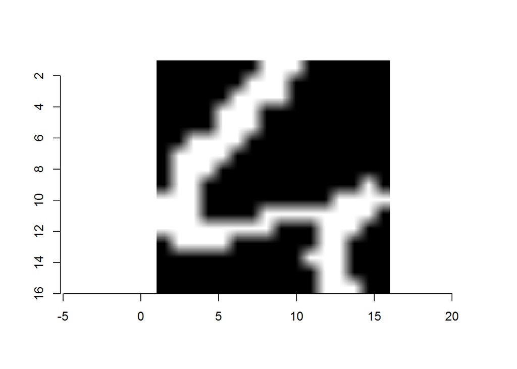

```r
img <- Digit[,-(257:266)]
Y <- apply(Digit[,257:266],1,function(x) sum(x*(0:9)))
i <- 81
im <- as.cimg(matrix((as.numeric(img[i,])),nr=16))
plot(im)
```

```r
pca <- prcomp(img,scale =F )
dim(pca$x)
```

```
## [1] 1592  256
```

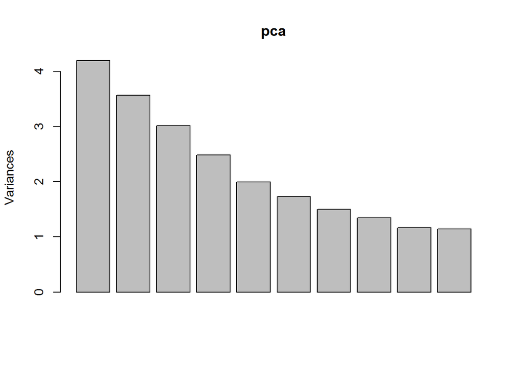

```r
plot(pca)
```

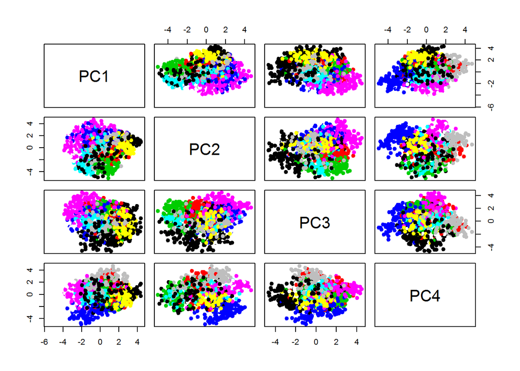

```r
pairs(pca$x[,1:4],col=Y,pch=19)
```

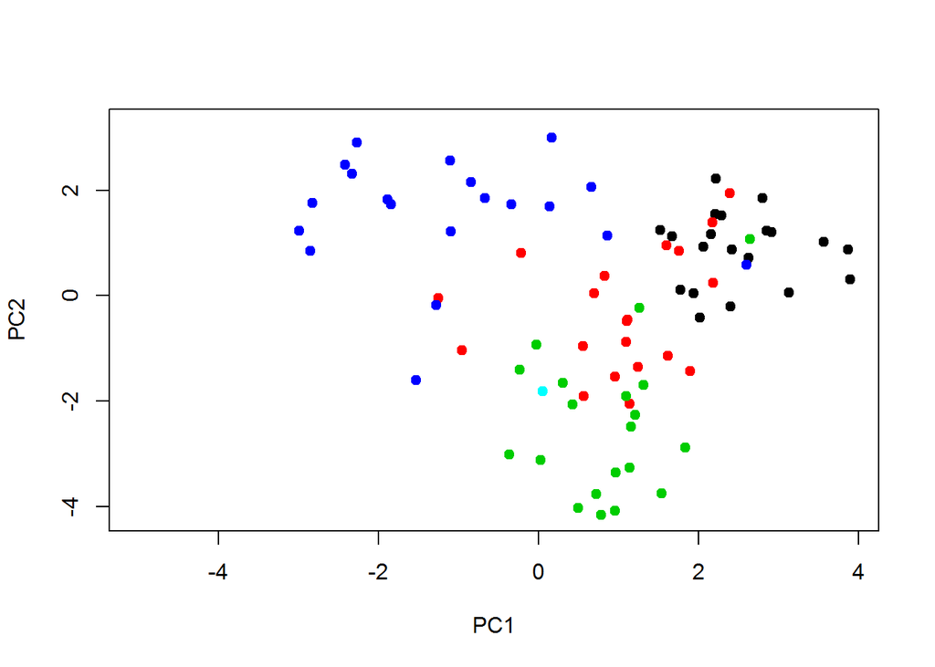

```
## integer(0)
```

```r
plot(pca$x[1:100,1:2],col=Y,pch=19)
identify(pca$x[1:100,1])
```

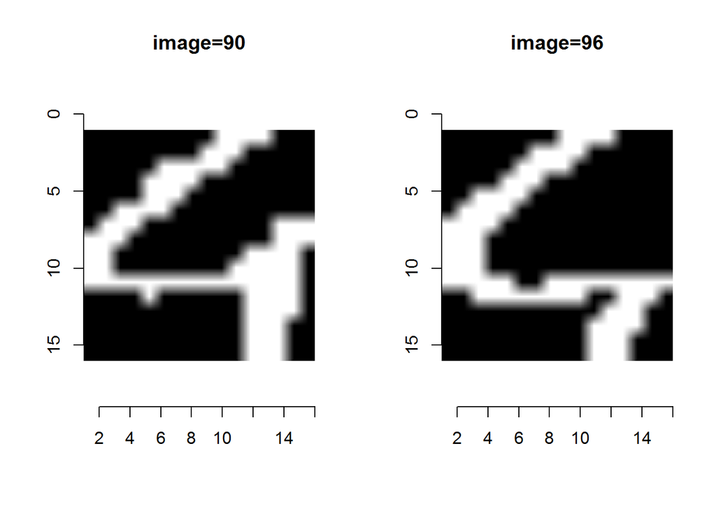

```r
im90 <- as.cimg(matrix((as.numeric(img[90,])),nr=16))
im96 <- as.cimg(matrix((as.numeric(img[96,])),nr=16))
par(mfrow=c(1,2))
plot(im90,main='image=90')
plot(im96,main='image=96')
```